# Hoeffding Confidence Intervals

11/05/2021

## Introduction

Confidence intervals are great for understanding how uncertain your metric estimates are and for understanding if one model is better than another.

For classification models there is one confidence interval that can be used for

- accuracy
- precision
- recall
- sensitivity
- specificity

that has the advantage of being **exact** and **nonparametric**. The Hoeffding Confidence Interval.

## Confidence Interval

An estimate \(\hat\theta_n\) of a parameter \(\theta\) (e.g. model accuracy) has a \((1-\delta)\)% confidence interval \(\hat\theta_n\pm\epsilon\) if with at least \(1-\delta\) probability the statement

\[ \hat\theta_n-\epsilon\leq\theta\leq\hat\theta_n+\epsilon \]

is true. The probability is with respect to the estimate \(\hat\theta_n\) and the error \(\epsilon\).

- **Exact**: statement is exact (e.g. non-asymptotic)
- **Nonparametric**: statement true for (almost) all distributions

## Interpretation 1

Assume we have some model with an unknown accuracy \(\theta\) and 100 independent test sets of size \(n\). For each test set \(i\) we:

1. Estimate the accuracy of the model \(\hat\theta_{n,i}\)
2. Calculate the error \(\epsilon_i\)
3. Construct a 99% confidence interval \(CI_i = \hat\theta_{n,i}\pm\epsilon_i\)

The phrase “99% confidence” means that out of the 100 confidence intervals we should expect at least 99 (which is 99% of the 100) to contain the unknown accuracy, \(\theta\in CI_i\).

## Interpretation 2

Approximately 99% confidence.

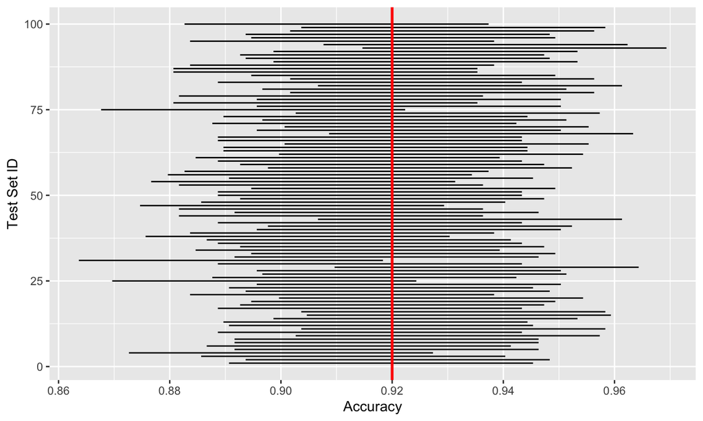

## Motivation

If you construct a confidence interval and the error is large for a given test set size you know that your metric estimate is uncertain and you should increase your test set size.

If you construct two confidence intervals for two different models and the confidence intervals do not overlap then you know that one model is *significantly* better than the other.

## Visualisation

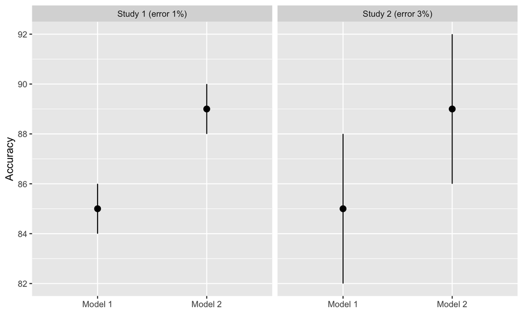

## Set up

For now assume that there are \(n\) binary random variables \(X_i\in\{0,1\}\), with expectation \(\theta\), and the average of these binary random variables

\[ \hat{\theta}_n=\frac{1}{n}\sum_{i=1}^n{X_i} \]

is used to estimate \(\theta\).

## Hoeffding Confidence Interval

Hoeffding proved that

\[ \hat{\theta}_n\pm\epsilon \]

is a \((1-\delta)\)% confidence interval with test set size of \(n\) if

\[ \epsilon=\sqrt{\frac{\ln(2/\delta)}{2n}}. \]

For example, a 95% confidence interval (i.e. \(\delta=0.05\)) with a test set size of \(n=1000\) has an error of approximately 4.29% with confidence interval \(\hat{\theta}_{1000}\pm0.0429\)

## Bound Issues

With small \(n\) sometimes \(\hat{\theta}_n-\epsilon<0\) or \(\hat{\theta}_n+\epsilon>1\). In this case we can redefine the upper and lower bounds as

\[ [\max\{\hat{\theta}_n-\epsilon, 0\}, \min\{\hat{\theta}_n+\epsilon, 1\}] \] and this remains a \((1-\delta)\)% confidence interval.

## Power Calculation

Hoeffding also proved that

\[ \hat{\theta}_n\pm\epsilon \]

is a \((1-\delta)\)% confidence interval with error \(\epsilon\) if

\[ n\geq\left\lceil\frac{\ln(2/\delta)}{2\epsilon^2}\right\rceil. \]

**This can be used to calculate the test set size for a given confidence \(\delta\) and error \(\epsilon\).**

A 99% confidence (\(\delta=0.01\)) and 1% error (\(\epsilon=0.01\)) corresponds to a test set size of \(n\geq26492\).

## Application to Metrics

For different metrics \(n\) has different values:

- **Accuracy**: number of examples
- **Precision**: number of examples classified as positive
- **Recall**: number of examples that are positive
- **Sensitivity**: number of examples that are positive
- **Specificity**: number of examples that are negative

## Code

This can all be done with a very simple python function:

```python
def hoeffding_interval(n, delta, estimate):
    epsilon = math.sqrt((math.log(2 / delta)) / (2 * n))
    return (max(estimate - epsilon, 0), min(estimate + epsilon, 1))
```

For example if my estimate \(\hat{\theta}_n=0.8\) then:

```python
>>> import math
>>> hoeffding_interval(100, 0.05, 0.8)
(0.6641898484259381, 0.935810151574062)
```